# IE 582 - Homework - 5

Serhat Arca

January 7, 2019

## 1. Introduction

Multiple- instance learning (MIL) is a variation on supervised learning.The aim of MIL is to classify a bag given its instance characteristics. In this homework, we are asked to work with Musk1 data and apply MIL on this data. Musk1 data consists of 92 molecules of which 47 are labeled as musks and 45 are labeled as non-musks. The aim is to predict whether new molecules will be musks or non-musks.

The following algorithm is used to transform instance-level information to bag-level represantation:

Step 1: Cluster instances with some clustering algorithm Step 2: For each bag: Calculate the distance of its instances to each cluster centroid (i.e. each instance of the bag is represented by a feature vector of length r) Step 3: Represent the bag as the average of its instance distances to the cluster centroids (a bag is represented by a feature vector of length r).

Two distance measures, namely Eucledian and Manhattan, are used in the 1st step. For each distance measure, the performance is evaluated by k-means and hierarchical clustering.

## 2. Results and Discussions

K-means and hierarchical clustering is used with two different distance measures to create the models. 10 different k-levels are used as part of model construction. The accuracies as a function of k-levels for a total of 4 different clustering techniques and distance measures are given in Figure 1

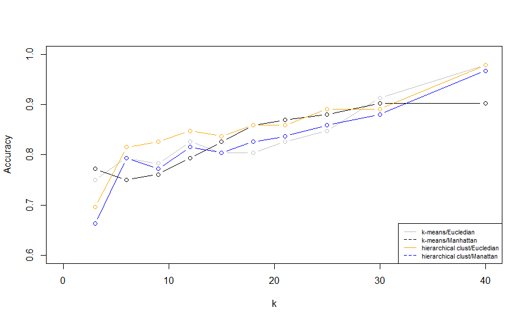

**Figure 1** - Accuracy results for differenet clustering techniques with Euclidean and Manhattan distances.

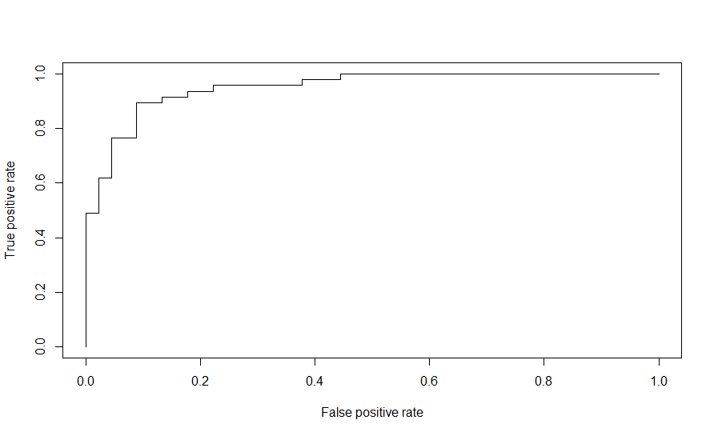

**Figure 2** - ROC curve for k-means algorithm with k-level=21 using Manhattan distance.

The area under the ROC curve is a mesure of accuracy. A high area indicates high accuracy. An investigation of Figure 2 reveals that the area under the ROC curve increases at low false positive rates. This means that the area under the curve increases at low values of x and it indicates high accuracy.

## 3. Appendix: Code

```r
require(stats)
require(TSdist)
require(cluster)
require(ROCR)
library(caret)

set.seed(123)

data=read.csv(file="C:/Users/07830/Desktop/Musk1.csv", header = FALSE, sep = ",")

d=c(3,6,9,12,15,18,21,25,30,40)
acc_Euc=array()
acc_Manhat=array()
acc_Euc_hier=array()
acc_Manhat_hier=array()

# function to find medoid in cluster i
clust.centroid = function(z, dat, clusters) {
  ind = (clusters == z)
  colMeans(dat[ind,])
}

for (i in 1:length(d)) {

k=d[i]
distEuc=data.frame()
distManhat=data.frame()
distEuc_hier=data.frame()
distManhat_hier=data.frame()

n=nrow(data)

# Euclidean  - kmeans

cluster_Euc=pam(data[,3:length(data)],k,metric = "euclidean")
center_Euc=cluster_Euc$medoids
#clusters=cluster$cluster

# Manhattan - kmeans

cluster_Manhat=pam(data[,3:length(data)],k,metric = "manhattan")
center_Manhat=cluster_Manhat$medoids

# Euclidean  - hierarchical
cluster_Euc_hier = hclust(dist(data[,3:length(data)], method = "euclidean"), method = "average")
cluster_Euc_h <- cutree(cluster_Euc_hier, k = k)

hier_center_Euc=NULL

for (s in 1:k) {
  hier_center_Euc <- rbind(hier_center_Euc, colMeans(data[,3:length(data)][cluster_Euc_h == s, , drop = FALSE]))
}

# Manhattan  - hierarchical
cluster_Manhat_hier = hclust(dist(data[,3:length(data)], method = "manhattan"), method = "average")
clust_Manhat_h <- cutree(cluster_Manhat_hier, k = k)

hier_center_Manhat=NULL

for (s in 1:k) {
  hier_center_Manhat <- rbind(hier_center_Manhat, colMeans(data[,3:length(data)][clust_Manhat_h == s, , drop = FALSE]))
}


for (j in 1:n) {
    for (p in 1:k){
      distEuc[j,p]=EuclideanDistance(as.double(data[j,3:length(data)]), as.vector(center_Euc[p,]))
      distManhat[j,p]=ManhattanDistance(as.double(data[j,3:length(data)]), as.vector(center_Manhat[p,]))
      distEuc_hier[j,p]=EuclideanDistance(as.double(data[j,3:length(data)]), as.vector(hier_center_Euc[p,]))
      distManhat_hier[j,p]=ManhattanDistance(as.double(data[j,3:length(data)]), as.vector(hier_center_Manhat[p,]))

  }}


dat_Euc = cbind(data[,1:2], distEuc)
dat_Manhat = cbind(data[,1:2], distManhat)
dat_Euc_hier = cbind(data[,1:2], distEuc_hier)
dat_Manhat_hier = cbind(data[,1:2], distManhat_hier)


dat_Euc_2= aggregate(dat_Euc, by=list(dat_Euc[,2]), mean)
dat_Manhat_2= aggregate(dat_Manhat, by=list(dat_Manhat[,2]), mean)
dat_Euc_2_hier= aggregate(dat_Euc_hier, by=list(dat_Euc_hier[,2]), mean)
dat_Manhat_2_hier= aggregate(dat_Manhat_hier, by=list(dat_Manhat_hier[,2]), mean)

# Lasso regression
dat_Euc_2[,c(1,3)]=NULL
dat_Manhat_2[,c(1,3)]=NULL
dat_Euc_2_hier[,c(1,3)]=NULL
dat_Manhat_2_hier[,c(1,3)]=NULL
#
class_Euc=as.factor(dat_Euc_2[,1])
class_Manhat=as.factor(dat_Manhat_2[,1])
class_Euc_hier=as.factor(dat_Euc_2_hier[,1])
class_Manhat_hier=as.factor(dat_Manhat_2_hier[,1])

m=k+1
colnames(dat_Euc_2) <- c(paste0("v", 1:m))
colnames(dat_Manhat_2) <- c(paste0("v", 1:m))
colnames(dat_Euc_2_hier) <- c(paste0("v", 1:m))
colnames(dat_Manhat_2_hier) <- c(paste0("v", 1:m))

# Euclidean  - kmeans - accuracy
model_Euc = train(as.factor(v1)~.,data=dat_Euc_2, method="pda", metric="Accuracy", maximize = TRUE,
             trControl=trainControl("cv",number=10))

predicted_Euc = predict(model_Euc, dat_Euc_2)
tbl_Euc=table(predicted_Euc, class_Euc)
acc_Euc[i]=sum(diag(tbl_Euc))/length(class_Euc)

# Manhattan - kmeans - accuracy
model_Manhat = train(as.factor(v1)~.,data=dat_Manhat_2, method="pda", metric="Accuracy", maximize = TRUE,
                trControl=trainControl("cv",number=10))

predicted_Manhat = predict(model_Manhat, dat_Manhat_2)
tbl_Manhat=table(predicted_Manhat, class_Manhat)
acc_Manhat[i]=sum(diag(tbl_Manhat))/length(class_Manhat)

# Euclidean  - hierarchical - accuracy
model_Euc_hier = train(as.factor(v1)~.,data=dat_Euc_2_hier, method="pda", metric="Accuracy", maximize = TRUE,
                trControl=trainControl("cv",number=10))

predicted_Euc_hier = predict(model_Euc_hier, dat_Euc_2_hier)
tbl_Euc_hier=table(predicted_Euc_hier, class_Euc_hier)
acc_Euc_hier[i]=sum(diag(tbl_Euc_hier))/length(class_Euc_hier)


# Manhattan  - hierarchical - accuracy
model_Manhat_hier = train(as.factor(v1)~.,data=dat_Manhat_2_hier, method="pda", metric="Accuracy", maximize = TRUE,
                  trControl=trainControl("cv",number=10))

predicted_Manhat_hier = predict(model_Manhat_hier, dat_Manhat_2_hier)
tbl_Manhat_hier=table(predicted_Manhat_hier, class_Manhat_hier)
acc_Manhat_hier[i]=sum(diag(tbl_Manhat_hier))/length(class_Manhat_hier)
}

# Plots
plot(d, acc_Euc, col="gray", type="b", ylab="Accuracy", xlab="k",
     xlim=c(0, 40), ylim=c(0.60, 1))
par(new=TRUE)
lines(d,acc_Manhat, ylab="Accuracy", xlab="k",type = "b",
     xlim=c(0, 40), ylim=c(0.60, 1))
par(new=TRUE)
lines(d, acc_Euc_hier, col="orange", ylab="Accuracy", xlab="k",type="b",
     xlim=c(0, 40), ylim=c(0.60, 1))
par(new=TRUE)
lines(d, acc_Manhat_hier, col="blue", ylab="Accuracy", xlab="k",type="b",
     xlim=c(0, 40), ylim=c(0.60, 1))
legend("bottomright", legend=c("k-means/Eucledian", "k-means/Manhattan", "hierarchical clust/Eucledian", "hierarchical clust/Manattan"),
       col=c("gray", "black", "orange","blue"), lty=1:2, cex=0.7)


# kmeans, k=21 with Manhattan distance
k= 21
m=k+1

cluster_final=pam(data[,3:length(data)],k,metric = "manhattan")
center_final=cluster_final$medoids

dist_final=data.frame()

for (t in 1:n) {
  for (g in 1:k){
    dist_final[t,g]=ManhattanDistance(as.double(data[t,3:length(data)]), as.vector(center_final[g,]))
  }}
dat_final = cbind(data[,1:2], dist_final)
dat_final_2= aggregate(dat_final, by=list(dat_final[,2]), mean)
dat_final_2[,c(1,3)]=NULL
class_final=as.factor(dat_final_2[,1])
colnames(dat_final_2) <- c(paste0("v", 1:m))

model_final = train(as.factor(v1)~.,data=dat_final_2, method="pda", metric="Accuracy", maximize = TRUE,
                trControl=trainControl("cv",number=10))

predicted_final = predict(model_final, dat_final_2, type = "prob")


pred <- prediction(predicted_final[,2], class_final)
perf <- performance(pred,"tpr","fpr")
plot(perf)
```